# PR8 - Apply, Aggregate

## 2.5. `aggregate` 함수

- 사용방식 : aggregate(목표변수, 기준변수, 함수)
- 결과 값을 데이터프레임으로 출력해주는 것이 가장 큰 장점임.
- 기준변수가 list로 입력되어야 한다.

```r
aggregate(income, list(Segment), mean)
```

```
##      Group.1        x
## 1  Moving up 53090.97
## 2 Suburb mix 55033.82
## 3  Travelers 62213.94
## 4  Urban hip 21681.93
```

```r
str(aggregate(income, list(Segment), mean))
```

```
## 'data.frame':    4 obs. of  2 variables:
##  $ Group.1: chr  "Moving up" "Suburb mix" "Travelers" "Urban hip"
##  $ x      : num  53091 55034 62214 21682
```

- 포뮬러를 사용하면 효과적이다(변수명 지정, 리스트 변환)

```r
aggregate(income ~ Segment, data = seg.df, mean)
```

```
##      Segment   income
## 1  Moving up 53090.97
## 2 Suburb mix 55033.82
## 3  Travelers 62213.94
## 4  Urban hip 21681.93
```

```r
aggregate(income ~ Segment + ownHome + subscribe, data = seg.df, mean)
```

```
##       Segment ownHome subscribe   income
## 1   Moving up   ownNo     subNo 55402.89
## 2  Suburb mix   ownNo     subNo 54579.99
## 3   Travelers   ownNo     subNo 65852.54
## 4   Urban hip   ownNo     subNo 21604.16
## 5   Moving up  ownYes     subNo 49898.85
## 6  Suburb mix  ownYes     subNo 55354.86
## 7   Travelers  ownYes     subNo 61749.71
## 8   Urban hip  ownYes     subNo 23993.93
## 9   Moving up   ownNo    subYes 50675.70
## 10 Suburb mix   ownNo    subYes 63753.97
## 11  Travelers   ownNo    subYes 48091.75
## 12  Urban hip   ownNo    subYes 20271.33
## 13  Moving up  ownYes    subYes 51359.44
## 14 Suburb mix  ownYes    subYes 52815.13
## 15  Travelers  ownYes    subYes 62944.64
## 16  Urban hip  ownYes    subYes 19320.64
```

## 2.6. `cut` 함수

- cut 함수는 연속형 변수를 특정 구간으로 구분하여 명목형 변수로 변환한다.
- cut(데이터, breaks = 구간수, labels = 구간 이름)

```r
cut.data = aggregate(income ~ Segment + ownHome + subscribe, data = seg.df, mean)
cut.data$income2 = cut(cut.data$income, breaks = seq(0, 70000, 10000))
cut.data$income2 = cut(
  cut.data$income,
  breaks = c(0, 20000, 30000, 40000, 50000, 60000, 70000),
  labels = c('2만이하', '2만-3만', '3만-4만', '4만-5만', '5만-6만', '6만이상')
)
cut.data
```

```
##       Segment ownHome subscribe   income income2
## 1   Moving up   ownNo     subNo 55402.89 5만-6만
## 2  Suburb mix   ownNo     subNo 54579.99 5만-6만
## 3   Travelers   ownNo     subNo 65852.54 6만이상
## 4   Urban hip   ownNo     subNo 21604.16 2만-3만
## 5   Moving up  ownYes     subNo 49898.85 4만-5만
## 6  Suburb mix  ownYes     subNo 55354.86 5만-6만
## 7   Travelers  ownYes     subNo 61749.71 6만이상
## 8   Urban hip  ownYes     subNo 23993.93 2만-3만
## 9   Moving up   ownNo    subYes 50675.70 5만-6만
## 10 Suburb mix   ownNo    subYes 63753.97 6만이상
## 11  Travelers   ownNo    subYes 48091.75 4만-5만
## 12  Urban hip   ownNo    subYes 20271.33 2만-3만
## 13  Moving up  ownYes    subYes 51359.44 5만-6만
## 14 Suburb mix  ownYes    subYes 52815.13 5만-6만
## 15  Travelers  ownYes    subYes 62944.64 6만이상
## 16  Urban hip  ownYes    subYes 19320.64 2만이하
```

## 2.7. `grep` 함수

```r
grep("ap", c("apple", "Apple", "apple2", "bbapple")) # ap를 포함하는 원소들의 위치
```

```
## [1] 1 3 4
```

```r
grep("ap", c("apple", "Apple", "apple2", "bbapple"), value = TRUE) # ap를 포함하는 원소
```

```
## [1] "apple"   "apple2"  "bbapple"
```

```r
grep("[1-3]",
     c("apple1", "apple2", "apple3", "apple4", "Apple1")) # 1, 2, 3을 포함하는 원소 위치
```

```
## [1] 1 2 3 5
```

```r
grepl("ap", c("apple", "Apple", "apple2", "bbapple")) # ap를 포함하는 원소들의 위치
```

```
## [1]  TRUE FALSE  TRUE  TRUE
```

- 공통된 패턴을 가진 자료들의 위치를 찾아서 위치 값을 활용해 데이터를 일괄 변환할 때 사용한다.

```r
seg.df$ownHome = as.character(seg.df$ownHome)
grep('Yes', seg.df$ownHome)
```

```
##   [1]   2   3   5   6  10  11  14  15  16  17  18  19  20  21  22  24  25  26
##  [19]  33  37  39  40  41  43  47  50  51  52  53  55  57  68  72  73  75  79
##  [37]  80  81  83  84  87  90  91  92  95  96  97  99 108 118 120 122 125 130
##  [55] 139 144 145 150 151 152 153 155 156 157 159 160 161 162 163 164 165 166
##  [73] 167 168 169 170 171 175 176 177 178 179 180 181 182 183 184 185 187 188
##  [91] 189 190 192 194 195 196 197 198 199 200 201 203 204 207 208 210 211 213
## [109] 214 215 216 220 221 223 224 225 226 228 231 232 236 238 240 241 247 252
## [127] 258 261 264 265 269 271 273 274 276 279 286 293 295 296 300
```

```r
head(seg.df)
```

```
##        age gender   income kids ownHome subscribe    Segment
## 1 47.31613   Male 49482.81    2   ownNo     subNo Suburb mix
## 2 31.38684   Male 35546.29    1  ownYes     subNo Suburb mix
## 3 43.20034   Male 44169.19    0  ownYes     subNo Suburb mix
## 4 37.31700 Female 81041.99    1   ownNo     subNo Suburb mix
## 5 40.95439 Female 79353.01    3  ownYes     subNo Suburb mix
## 6 43.03387   Male 58143.36    4  ownYes     subNo Suburb mix
```

```r
seg.df$ownHome[grep('Yes', seg.df$ownHome)] = 'Yes'
head(seg.df)
```

```
##        age gender   income kids ownHome subscribe    Segment
## 1 47.31613   Male 49482.81    2   ownNo     subNo Suburb mix
## 2 31.38684   Male 35546.29    1     Yes     subNo Suburb mix
## 3 43.20034   Male 44169.19    0     Yes     subNo Suburb mix
## 4 37.31700 Female 81041.99    1   ownNo     subNo Suburb mix
## 5 40.95439 Female 79353.01    3     Yes     subNo Suburb mix
## 6 43.03387   Male 58143.36    4     Yes     subNo Suburb mix
```

## 2.8. `gsub` 함수

- 현재 데이터의 Segment 컬럼에 한 칸 띄워쓰기를 없애고 싶을 때, 다음과 같이 사용한다.

```r
seg.df$Segment = gsub(" ", "", seg.df$Segment)
head(seg.df)
```

```
##        age gender   income kids ownHome subscribe   Segment
## 1 47.31613   Male 49482.81    2   ownNo     subNo Suburbmix
## 2 31.38684   Male 35546.29    1     Yes     subNo Suburbmix
## 3 43.20034   Male 44169.19    0     Yes     subNo Suburbmix
## 4 37.31700 Female 81041.99    1   ownNo     subNo Suburbmix
## 5 40.95439 Female 79353.01    3     Yes     subNo Suburbmix
## 6 43.03387   Male 58143.36    4     Yes     subNo Suburbmix
```

# PR8 연습문제

## PR8 연습문제 1 번

```r
data_clickstream <-
  read.csv(
    'https://ajouackr-my.sharepoint.com/:x:/g/personal/sehyoung66_ajou_ac_kr/EVU9rdRGBN5DpiLkyYzqte8Boxyafvr9USquqVy4lv7Fbg?e=GCTSlv&download=1'
  )
# head(data_clickstream)

appliedValues = lapply(data_clickstream[, c('order', 'price')], function(nums) {
  return((nums - min(nums)) / (max(nums) - min(nums)))
})
data_clickstream$normed_order = appliedValues$order
data_clickstream$normed_price = appliedValues$price

head(data_clickstream)
```

```
##   year month day order country session.ID page.1..main.category.
## 1 2008     4   1     1      29          1                      1
## 2 2008     4   1     2      29          1                      1
## 3 2008     4   1     3      29          1                      2
## 4 2008     4   1     4      29          1                      2
## 5 2008     4   1     5      29          1                      2
## 6 2008     4   1     6      29          1                      3
##   page.2..clothing.model. colour location model.photography price price.2 page
## 1                     A13      1        5                 1    28       2    1
## 2                     A16      1        6                 1    33       2    1
## 3                      B4     10        2                 1    52       1    1
## 4                     B17      6        6                 2    38       2    1
## 5                      B8      4        3                 2    52       1    1
## 6                     C56      6        1                 2    57       1    4
##   normed_order normed_price
## 1  0.000000000     0.156250
## 2  0.005154639     0.234375
## 3  0.010309278     0.531250
## 4  0.015463918     0.312500
## 5  0.020618557     0.531250
## 6  0.025773196     0.609375
```

## PR8 연습문제 2 번

```r
data_by_artist <-
  read.csv(
    "https://ajouackr-my.sharepoint.com/:x:/g/personal/sehyoung66_ajou_ac_kr/ETc8rGQFYutIi9fCkVbPAVkB9NavPEObup73YWdo6aDPQA?e=ghYi9y&download=1"
  )

artist_devid = data_by_artist[grep('David', data_by_artist$artists),]
head(artist_devid)
```

```
##      mode count acousticness                 artists danceability duration_ms
## 4826    1     1    0.8050000          Clifford David       0.4120    280427.0
## 5135    0    16    0.2867375             Craig David       0.6365    236942.2
## 5528    1     1    0.2060000         Dallas Davidson       0.6210    155040.0
## 5816    1     2    0.6300000 David "Frazeman" Frazer       0.2900    256933.0
## 5817    1     6    0.3166667           David & David       0.6720    292564.3
## 5818    1     2    0.0935500            David Ahlert       0.4940    281233.0
##         energy instrumentalness  liveness   loudness speechiness    tempo
## 4826 0.4590000      0.000000000 0.1270000  -9.667000   0.1380000  87.3780
## 5135 0.7228750      0.001102523 0.1394187  -6.668563   0.0425625 109.8799
## 5528 0.8410000      0.000001070 0.0620000  -3.909000   0.1470000 171.8630
## 5816 0.5150000      0.000000000 0.0840000  -9.420000   0.0865000  77.2130
## 5817 0.6136667      0.000190330 0.2003000 -13.417000   0.0400000 114.5317
## 5818 0.5715000      0.000114150 0.0581000 -13.754500   0.0364000 128.3740
##      valence popularity key
## 4826 0.54900    18.0000   9
## 5135 0.77075    60.4375   4
## 5528 0.72200    48.0000   2
## 5816 0.28000    42.0000   9
## 5817 0.77000    33.0000   0
## 5818 0.58500    40.5000   9
```

## PR8 연습문제 3 번

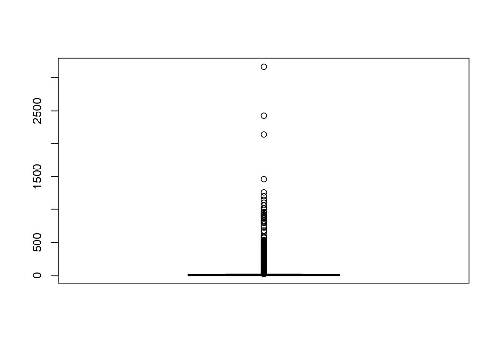

```r
boxplot(data_by_artist$count)
```

```r
count_label = cut(
  data_by_artist$count,
  breaks = c(0, 100, 200, 300, 400, Inf),
  labels = c('100이하', '100에서200', '200에서300', '300에서400', '400이상')
)
str(count_label)
```

```
##  Factor w/ 5 levels "100이하","100에서200",..: 1 1 1 1 1 1 1 1 2 1 ...
```

## PR8 연습문제 4 번

```r
energy_mean_by_count = aggregate(data_by_artist$energy ~ count_label, data = data_by_artist, mean)
names(energy_mean_by_count) = c('count', 'energy_mean')
energy_mean_by_count
```

```
##        count energy_mean
## 1    100이하   0.4982557
## 2 100에서200   0.4961634
## 3 200에서300   0.4550065
## 4 300에서400   0.4180836
## 5    400이상   0.3487298
```

## PR8 도전문제

아래 코드를 통해 data_by_artist 자료의 popularity의 사분위수를 기준으로 자료를 4개의 구간으로 나누고, 각 구간에 해당하는 열의 energy 평균을 구하고자 한다.

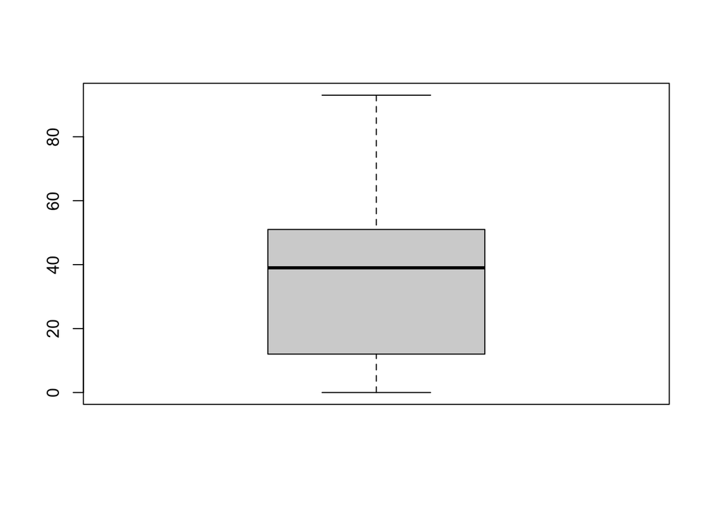

```r
# 박스플롯으로 data_by_artist의 popularity 열의 분포를 확인
boxplot(data_by_artist$popularity)
```

```r
# data_by_artist의 popularity 열의 4분위수 확인
popularity_quantile = quantile(data_by_artist$popularity)
popularity_quantile
```

```
##   0%  25%  50%  75% 100%
##    0   12   39   51   93
```

```r
# data_by_artist$popularity 열의 데이터를 ~ 12, 12 ~ 39, 39 ~ 51, 51 ~ 총 4개 구간을 나누고, popularity_label 이라는 변수로 추가
popularity_label = cut(
  data_by_artist$popularity,
  breaks = c(popularity_quantile),
  labels = c('12이하', '12에서39', '39에서51', '51이상')
)
# 위의 popularity_label를 사용하여 popularity_label 별로 energy의 평균을 계산
energy_mean_by_popularity = aggregate(data_by_artist$energy ~ popularity_label, data_by_artist, mean)
energy_mean_by_popularity
```

```
##   popularity_label data_by_artist$energy
## 1           12이하             0.3117783
## 2         12에서39             0.4744986
## 3         39에서51             0.5748838
## 4           51이상             0.6056084
```

아래 코드를 통해 data_by_artist 자료의 tempo의 사분위수를 기준으로 자료를 4개의 구간으로 나누고, 각 구간에 해당하는 열의 popularity 평균을 구하고자 한다.

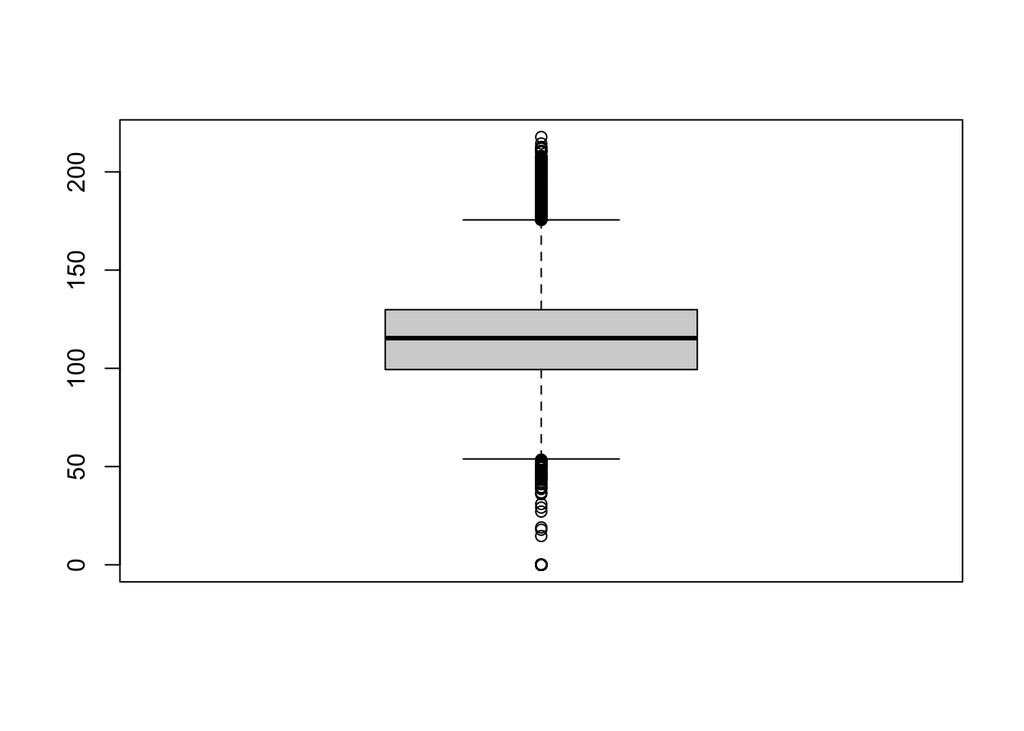

```r
# 박스플롯으로 data_by_artist의 tempo 열의 분포를 확인
boxplot(data_by_artist$tempo)
```

```r
# data_by_artist의 tempo 열의 4분위수 확인
tempo_quantile = quantile(data_by_artist$tempo)
tempo_quantile
```

```
##       0%      25%      50%      75%     100%
##   0.0000  99.3665 115.3574 129.8488 217.7430
```

```r
# data_by_artist$tempo 열의 데이터를 ~ 99.3665, 99.3665 ~ 115.3574, 115.3574 ~ 129.8488, 129.8488 ~ 총 4개 구간을 나누고, tempo_label이라는 변수로 추가
tempo_label = cut(
  data_by_artist$tempo,
  breaks = c(tempo_quantile),
  labels = c(
    '99.3665이하',
    '99.3665이하115.3574이상',
    '115.3574이하129.8488이상',
    '129.8488이상'
  )
)
# 위의 tempo_label를 사용하여 tempo_label 별로 popularity의 평균을 계산
popularity_mean_by_tempo = aggregate(data_by_artist$popularity ~ tempo_label, data_by_artist, mean)
popularity_mean_by_tempo
```

```
##                tempo_label data_by_artist$popularity
## 1              99.3665이하                  29.75061
## 2  99.3665이하115.3574이상                  31.79021
## 3 115.3574이하129.8488이상                  36.10589
## 4             129.8488이상                  38.39199
```

위에서 계산한 tempo_quantile을 사용하여 이상치에 해당하는 tempo 열 데이터를 가진 행을 제거하여 tempo_label 별로 popularity의 평균을 계산하고자 한다.

```r
# 이 문단에서의 이상치: ~ Q1 + 1.5 * IQR, Q3 + 1.5 * IQR ~
iqr_range = list(
  min = tempo_quantile[2] - 1.5 * (tempo_quantile[4] - tempo_quantile[2]),
  max = tempo_quantile[4] + 1.5 * (tempo_quantile[4] - tempo_quantile[2])
)
iqr_range
```

```
## $min
##      25%
## 53.64312
##
## $max
##      75%
## 175.5721
```

```r
# data_by_artist$tempo 열의 데이터를 53.64312 ~ 99.3665, 99.3665 ~ 115.3574, 115.3574 ~ 129.8488, 129.8488 ~ 175.5721 총 4개 구간을 나누고, rm_tempo_label이라는 변수로 추가
rm_tempo_label = cut(
  data_by_artist$tempo,
  breaks = c(
    iqr_range$min,
    tempo_quantile[2],
    tempo_quantile[3],
    tempo_quantile[4],
    iqr_range$max
  ),
  labels = c(
    '53.64312이상99.3665이하',
    '99.3665이하115.3574이상',
    '115.3574이하129.8488이상',
    '129.8488이상175.5721이하'
  )
)
# 위의 rm_tempo_label를 사용하여 rm_tempo_label 별로 popularity의 평균을 계산
popularity_mean_by_rm_tempo = aggregate(data_by_artist$popularity ~ rm_tempo_label,
                                        data_by_artist,
                                        mean)
popularity_mean_by_rm_tempo
```

```
##             rm_tempo_label data_by_artist$popularity
## 1  53.64312이상99.3665이하                  29.69271
## 2  99.3665이하115.3574이상                  31.79021
## 3 115.3574이하129.8488이상                  36.10589
## 4 129.8488이상175.5721이하                  38.65574
```